# Introduction to Gradient Descent: An Optimization Journey

From Mathematical Theory to Practical Implementation

Author

Dr. Aydede

Published

November 24, 2025

# 1 Introduction: Why Gradient Descent?

## 1.1 The Optimization Challenge

In Week 1, we learned three approaches to finding regression coefficients:

1. **Probabilistic Approach**: Using conditional expectations
2. **Covariance Approach**: Using the orthogonality condition
3. **Optimization Approach**: Minimizing the Residual Sum of Squares (RSS)

For simple linear regression, we derived the closed-form solution:
$$\beta = (X^T X)^{-1} X^T y$$

But what happens when:

- The matrix $(X^T X)$ is too large to invert efficiently?
- We have millions of parameters (like in neural networks)?
- The objective function has no closed-form solution?
- We want to optimize non-linear models?

This is where **gradient descent** becomes essential.

## 1.2 What is Gradient Descent?

**Gradient descent** is an iterative optimization algorithm that finds the minimum of a function by repeatedly moving in the direction of steepest descent.

Think of it like this:

- You’re standing on a hillside in thick fog
- You can’t see the valley below (the minimum)
- But you can feel the slope under your feet
- You take steps downhill, and eventually reach the bottom

The “slope” is the gradient, and the “steps” are our parameter updates.

## 1.3 Key Concepts We’ll Cover

# 2 Building Intuition: A Simple Example

## 2.1 Understanding the Gradient: Direction and Magnitude

Before we dive into the mathematics, let’s build a figurative understanding of what the gradient tells us.

**The gradient is the slope of our cost function.** It tells us two crucial things:

1. **Direction**: Which way to go (uphill or downhill)
2. **Magnitude**: How steep the hill is (how big our step should be)

Think of it this way:

- You’re standing on a hillside and you measure the slope under your feet
- If the slope is **positive** (+), you’re facing uphill → to go down, you need to move **backwards** (reduce x)
- If the slope is **negative** (-), you’re facing downhill → to go down, you need to move **forwards** (increase x)
- The **steeper** the slope (larger magnitude), the **bigger** the step you can safely take
- The **flatter** the slope (smaller magnitude), the **smaller** the step you should take (you’re near the bottom!)

### 2.1.1 Visual Intuition

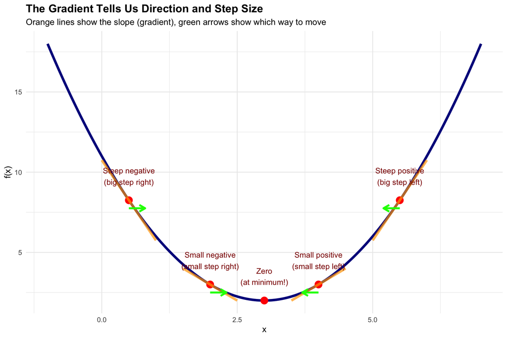

### 2.1.2 The Decision Process at Each Point

How the Gradient Guides Our Decisions

| Position | f(x) | Gradient | Sign | Magnitude | Direction | Step Size |
| --- | --- | --- | --- | --- | --- | --- |
| x = 0.5 | 8.25 | -5 | Negative (-) | Large (5) | Move RIGHT → | Big step |
| x = 2 | 3.00 | -2 | Negative (-) | Small (2) | Move RIGHT → | Small step |
| x = 3 | 2.00 | 0 | Zero | Zero | STOP! ✓ | No step |
| x = 4 | 3.00 | 2 | Positive (+) | Small (2) | Move LEFT ← | Small step |
| x = 5.5 | 8.25 | 5 | Positive (+) | Large (5) | Move LEFT ← | Big step |

### 2.1.3 The Update Rule Decoded

Now we can understand the gradient descent update rule intuitively:

$$x_{new} = x_{current} - \alpha \cdot \text{gradient}$$

Breaking this down:

- **If gradient is positive** (+5): We subtract a positive number → x decreases → we move left
- **If gradient is negative** (-5): We subtract a negative number → x increases → we move right
- **Large gradient** (±10): Big change in x → big step
- **Small gradient** (±0.1): Small change in x → small step
- **Learning rate α**: Controls how much we trust the gradient (like a “caution factor”)

Concrete Examples of the Update Rule (α = 0.1)

| Current x | Gradient | α | Calculation | New x | Direction |
| --- | --- | --- | --- | --- | --- |
| 0.5 | -5 | 0.1 | 0.5 - 0.1 × -5 | 1.0 | RIGHT → |
| 5.5 | 5 | 0.1 | 5.5 - 0.1 × 5 | 5.0 | LEFT ← |
| 2.0 | -2 | 0.1 | 2 - 0.1 × -2 | 2.2 | RIGHT → |
| 4.0 | 2 | 0.1 | 4 - 0.1 × 2 | 3.8 | LEFT ← |

```
✓ Notice: Negative gradient → x increases (move right)
```

```
✓ Notice: Positive gradient → x decreases (move left)
```

```
✓ Always moving toward x = 3 (the minimum)!
```